# Integration PTM-features and total proteome

2025-07-03

This vignette demonstrates how to **integrate and visualize PTM (Post-Translational Modification) features with total proteome data**. The analysis combines phosphorylation site information with overall protein expression to understand both **differential expression** and **differential usage** of modification sites.

## Overview

This workflow performs two main types of analysis:

1. **Differential PTM Feature Expression (DPE)** - How much each modification site changes in abundance
2. **Differential PTM Feature Usage (DPU)** - How the usage/occupancy of modification sites changes relative to total protein

The analysis creates N-to-C plots showing modification sites along protein backbones with their expression and usage changes.

# Data Setup and Configuration

## Setting up project parameters

This section defines the project identifiers and analysis type. The `ptm_feature` parameter determines whether we analyze single phosphorylation sites or multi-site patterns.

```r
wu_id <- "CustomPhosphoAnalysis"
fgcz_project <- "PTM_example"
oid_fgcz <- "fgcz_project"
ptm_feature <- "singlesite"


project_dir <- "../inst/PTM_example/"
tot_file <- file.path(
  project_dir,
  "DEA_20250703_WUtotal_proteome_vsn/Results_WU_total_proteome/DE_WUtotal_proteome.xlsx"
)

if (ptm_feature == "multisite") {
  ptm_file <- file.path(
    project_dir,
    "DEA_20250703_WUmultisite_PTM_vsn/Results_WU_multisite_PTM/DE_WUmultisite_PTM.xlsx"
  )
} else if (ptm_feature == "singlesite") {
  ptm_file <- file.path(
    project_dir,
    "DEA_20250703_WUsinglesite_PTM_vsn/Results_WU_singlesite_PTM/DE_WUsinglesite_PTM.xlsx"
  )
}

# Directory paths
file.exists(tot_file)
```

```
## [1] TRUE
```

```r
file.exists(ptm_file)
```

```
## [1] TRUE
```

## Creating results directory

Sets up the output directory with a timestamped name for organizing results.

```r
datetoday <- format(Sys.Date(), "%Y%m%d")
descri <- wu_id
res_dir <- file.path(project_dir, paste0(fgcz_project, "_", datetoday, "_", ptm_feature, "_", descri))

# Create results directory
if (!dir.exists(res_dir)) {
  dir.create(res_dir, recursive = TRUE)
}
```

## Defining analysis parameters

Sets the statistical thresholds and column mapping for joining total proteome and PTM data.

```r
fdr_threshold <- 0.01
join_column <- c("fasta.id" = "protein_Id", "contrast", "description", "protein_length")
suffix_a <- ".site"
suffix_b <- ".protein"
```

## Loading and preprocessing data

Loads both total proteome and PTM data, filters out contaminants, and ensures data quality.

```r
required_cols <- c("protein_Id", "protein_length", "contrast")
tot_res <- load_and_preprocess_data(tot_file, required_cols)
tot_res <- filter_contaminants(tot_res)
phospho_res <- load_and_preprocess_data(ptm_file, required_cols)
phospho_res <- filter_contaminants(phospho_res)
```

## Combining PTM and total proteome data

Joins the phosphorylation site data with total protein data to enable integrated analysis. This creates a dataset where each phosphorylation site is linked to its corresponding protein-level measurements.

```r
combined_site_prot <- dplyr::left_join(
  phospho_res,
  tot_res,
  by = join_column,
  suffix = c(suffix_a, suffix_b)
)
combined_site_prot$contrast |> table()
```

```
##
##     interaction_KO_vs_WT_at_Early_vs_Late
##                                     21733
## interaction_KO_vs_WT_at_Early_vs_Uninfect
##                                     21733
##  interaction_KO_vs_WT_at_Late_vs_Uninfect
##                                     21733
##                                  KO_vs_WT
##                                     21733
##                         KO_vs_WT_at_Early
##                                     21733
##                          KO_vs_WT_at_Late
##                                     21733
##                      KO_vs_WT_at_Uninfect
##                                     21733
```

# Differential PTM Feature Expression (DPE)

## Creating N-to-C expression plots

Generates plots showing phosphorylation sites along protein backbones with their differential expression values. The plots distinguish between multi-site and single-site analyses.

```r
if (ptm_feature == "multisite") {
  combined_site_prot_long <- explode_multisites(combined_site_prot)
  plot_data <- n_to_c_expression(combined_site_prot_long, "KO_vs_WT_at_Uninfect", 0.01)
} else if (ptm_feature == "singlesite") {
  plot_data <- n_to_c_expression(combined_site_prot, "KO_vs_WT_at_Uninfect", 0.01)
}
```

## Example plots for specific proteins

### Protein Q8C0J2

Shows the N-to-C plot for protein Q8C0J2, displaying phosphorylation sites along the protein backbone with their expression changes.

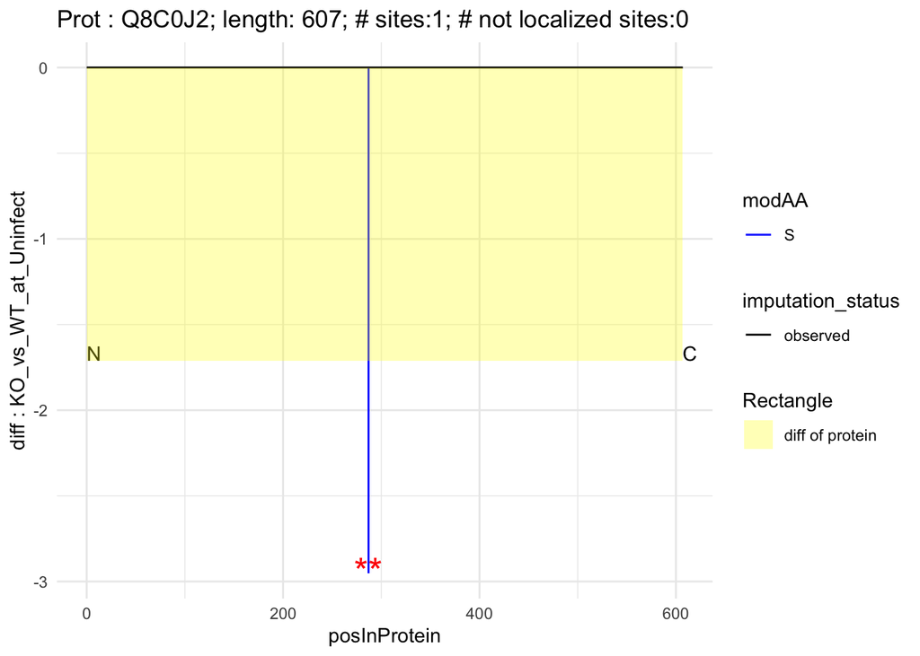

Q8C0J2

```r
x1 <- which(plot_data$protein_Id == "Q8C0J2")
plot_data$plot[[x1]]
```

```r
knitr::kable(plot_data$data[[x1]])
```

| site | diff.protein | diff.site | FDR.site | posInProtein | modAA | imputation_status |
| --- | --- | --- | --- | --- | --- | --- |
| Q8C0J2_S287~sVSSIPVPQDIMDTHPASGK | -1.710966 | -2.952249 | 2.2e-06 | 287 | S | observed |

### Protein Q64337

Shows the N-to-C plot for protein Q64337, another example of how phosphorylation sites change in expression.

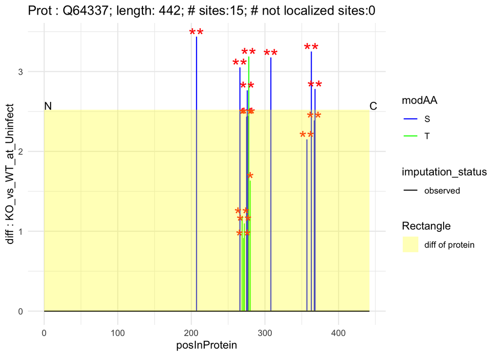

Q64337

```r
x1 <- which(plot_data$protein_Id == "Q64337")
plot_data$plot[[x1]]
```

```r
knitr::kable(plot_data$data[[x1]])
```

| site | diff.protein | diff.site | FDR.site | posInProtein | modAA | imputation_status |
| --- | --- | --- | --- | --- | --- | --- |
| Q64337_S207~HGHFGWPGWEMGPPGNWsPRPPR | 2.521616 | 3.4369798 | 0.0195844 | 207 | S | observed |
| Q64337_S266~sRLTPTTPESSSTGTEDK | 2.521616 | 3.0520914 | 0.0002013 | 266 | S | observed |
| Q64337_S275~LTPTTPEsSSTGTEDK | 2.521616 | 2.4357438 | 0.0061802 | 275 | S | observed |
| Q64337_S276~LTPTTPESsSTGTEDK | 2.521616 | 2.7647517 | 0.0017541 | 276 | S | observed |
| Q64337_S277~LTPTTPESSsTGTEDK | 2.521616 | 2.4430403 | 0.0001093 | 277 | S | observed |
| Q64337_S308~PDGAGEGPAQsLTEQMK | 2.521616 | 3.1765968 | 0.0008090 | 308 | S | observed |
| Q64337_S357~EVDPSTGELQsLQMPESEGPSSLDPSQEGPTGLK | 2.521616 | 2.1504854 | 0.0014726 | 357 | S | observed |
| Q64337_S363~EVDPSTGELQSLQMPEsEGPSSLDPSQEGPTGLK | 2.521616 | 3.2510655 | 0.0003098 | 363 | S | observed |
| Q64337_S367~EVDPSTGELQSLQMPESEGPsSLDPSQEGPTGLK | 2.521616 | 2.3884584 | 0.0000287 | 367 | S | observed |
| Q64337_S368~EVDPSTGELQSLQMPESEGPSsLDPSQEGPTGLK | 2.521616 | 2.7820922 | 0.0000001 | 368 | S | observed |
| Q64337_T269~LtPTTPESSSTGTEDK;RSRLtPTTPESSSTGTEDK;RSRLtPTTPESSSTGTEDK;SRLtPTTPESSSTGTEDK | 2.521616 | 1.1927179 | 0.0004245 | 269 | T | observed |
| Q64337_T271~LTPtTPESSSTGTEDK;RSRLTPtTPESSSTGTEDK | 2.521616 | 0.9153875 | 0.0267744 | 271 | T | observed |
| Q64337_T272~LTPTtPESSSTGTEDK | 2.521616 | 1.0981107 | 0.0019473 | 272 | T | observed |
| Q64337_T278~LTPTTPESSStGTEDK | 2.521616 | 3.1883960 | 0.0008426 | 278 | T | observed |
| Q64337_T280~LTPTTPESSSTGtEDK | 2.521616 | 1.6340737 | 0.0886744 | 280 | T | observed |

## Saving expression plots

Exports all N-to-C expression plots to a PDF file for further analysis and presentation.

```r
# Create plots
pdf(file.path(res_dir, "Site_differential_Expression.pdf"))
for (i in seq_len(100)) {
  print(plot_data$plot[[i]])
}
dev.off()
```

# Differential PTM Feature Usage (DPU)

This analysis examines how the **usage/occupancy** of phosphorylation sites changes relative to total protein abundance. This reveals whether changes in phosphorylation are due to changes in site usage or simply changes in total protein abundance.

## Computing PTM feature usage

Statistics used for testing differences of differences (fold changes)

$$\Delta_I = \log_2FC_{PTM} - \log_2FC_{Protein}$$

$$SE_I = \sqrt{SE_{PTM}^2 + SE_{Protein}^2}$$

$$df_I = (SE_{PTM}^2 + SE_{Protein}^2)^2 \biggm/
(\frac{SE_{PTM}^4}{DF_{PTM}} + \frac{SE_{Protein}^4}{DF_{Protein}})$$

The `test_diff` function calculates the difference of differences between PTM and total proteome data, revealing site-specific usage changes.

```r
combined_test_diff <- prophosqua::test_diff(phospho_res, tot_res, join_column = join_column)
```

## Creating N-to-C usage plots

Generates plots showing differential usage of phosphorylation sites. These plots reveal which sites are being used more or less actively, independent of total protein changes.

```r
if (ptm_feature == "multisite") {
  combined_test_diff_long <- explode_multisites(combined_test_diff)
  plot_data <- n_to_c_usage(combined_test_diff_long, "KO_vs_WT_at_Uninfect", FDR_threshold = 0.05)
} else if (ptm_feature == "singlesite") {
  plot_data <- n_to_c_usage(combined_test_diff, "KO_vs_WT_at_Uninfect", FDR_threshold = 0.05)
}
```

## Example usage plot

### PTM Feature Usage for Q64337

Shows how the usage of phosphorylation sites on protein Q64337 changes between experimental conditions.

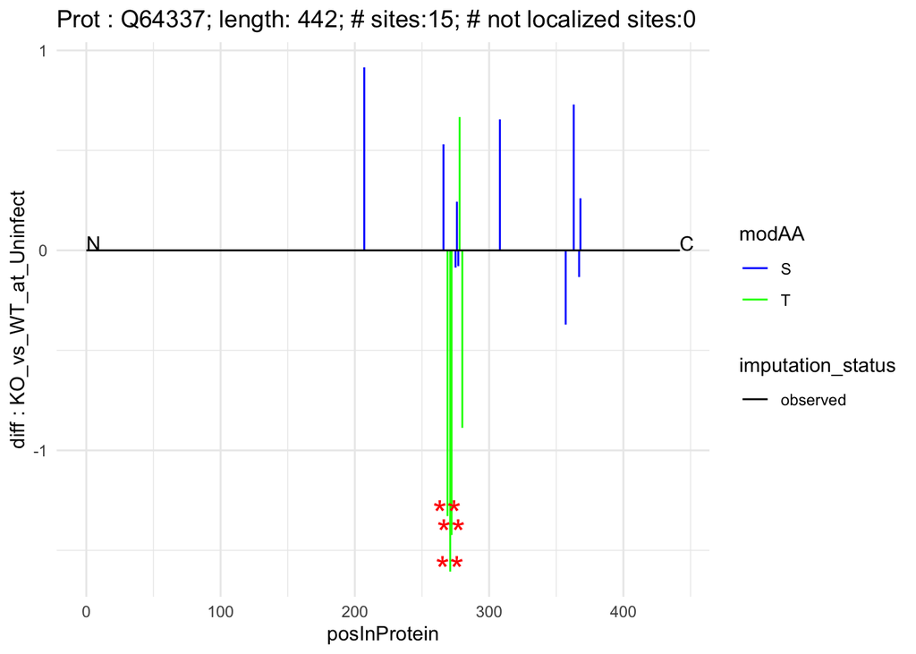

PTM feature usage for Q64337

```r
x1 <- which(plot_data$protein_Id == "Q64337")

plot_data$plot[[x1]]
```

```r
knitr::kable(plot_data$data[[x1]])
```

| site | diff_diff | FDR_I | posInProtein | modAA | imputation_status |
| --- | --- | --- | --- | --- | --- |
| Q64337_S207~HGHFGWPGWEMGPPGNWsPRPPR | 0.9153642 | 0.8112814 | 207 | S | observed |
| Q64337_S266~sRLTPTTPESSSTGTEDK | 0.5304758 | 0.7053864 | 266 | S | observed |
| Q64337_S275~LTPTTPEsSSTGTEDK | -0.0858718 | 0.9683255 | 275 | S | observed |
| Q64337_S276~LTPTTPESsSTGTEDK | 0.2431361 | 0.8959375 | 276 | S | observed |
| Q64337_S277~LTPTTPESSsTGTEDK | -0.0785753 | 0.9662564 | 277 | S | observed |
| Q64337_S308~PDGAGEGPAQsLTEQMK | 0.6549813 | 0.7104838 | 308 | S | observed |
| Q64337_S357~EVDPSTGELQsLQMPESEGPSSLDPSQEGPTGLK | -0.3711302 | 0.8196877 | 357 | S | observed |
| Q64337_S363~EVDPSTGELQSLQMPEsEGPSSLDPSQEGPTGLK | 0.7294499 | 0.5835007 | 363 | S | observed |
| Q64337_S367~EVDPSTGELQSLQMPESEGPsSLDPSQEGPTGLK | -0.1331572 | 0.9374273 | 367 | S | observed |
| Q64337_S368~EVDPSTGELQSLQMPESEGPSsLDPSQEGPTGLK | 0.2604767 | 0.8585026 | 368 | S | observed |
| Q64337_T269~LtPTTPESSSTGTEDK;RSRLtPTTPESSSTGTEDK;RSRLtPTTPESSSTGTEDK;SRLtPTTPESSSTGTEDK | -1.3288977 | 0.0419374 | 269 | T | observed |
| Q64337_T271~LTPtTPESSSTGTEDK;RSRLTPtTPESSSTGTEDK | -1.6062281 | 0.0227595 | 271 | T | observed |
| Q64337_T272~LTPTtPESSSTGTEDK | -1.4235049 | 0.0298494 | 272 | T | observed |
| Q64337_T278~LTPTTPESSStGTEDK | 0.6667804 | 0.7086770 | 278 | T | observed |
| Q64337_T280~LTPTTPESSSTGtEDK | -0.8875419 | 0.7569645 | 280 | T | observed |

## Saving usage plots

Exports all N-to-C usage plots to a PDF file.

```r
pdf(file.path(res_dir, "Site_differential_UsageChange.pdf"))
for (i in seq_len(100)) {
  print(plot_data$plot[[i]])
}
dev.off()
```

# Report Generation

## Setting up report configuration

Creates the configuration object needed for generating the interactive HTML report.

```r
drumm <- prolfquapp::make_DEA_config_R6(
  PROJECTID = fgcz_project,
  ORDERID = oid_fgcz,
  WORKUNITID = descri
)
# Copy integration files
prophosqua::copy_phospho_integration()
```

```
## [1] "/Users/witoldwolski/__checkout/prophosqua/vignettes/_Overview_PhosphoAndIntegration_site.Rmd"
## [2] "/Users/witoldwolski/__checkout/prophosqua/vignettes/bibliography2025.bib"
```

## Rendering the HTML report

Generates an interactive HTML report with comprehensive analysis results, including tables, plots, and statistical summaries.

```r
# Render HTML report
rmarkdown::render(
  "_Overview_PhosphoAndIntegration_site.Rmd",
  params = list(
    data = combined_test_diff,
    grp = drumm,
    phosres = phospho_res
  ),
  output_format = bookdown::html_document2(toc = TRUE, toc_float = TRUE),
  envir = new.env(parent = globalenv())
)



# Copy HTML report to results directory
file.copy(
  from = "_Overview_PhosphoAndIntegration_site.html",
  to = file.path(res_dir, "Result_phosphoAndIntegration.html")
)
```

## Saving results to Excel

Exports the integrated analysis results to an Excel file for further analysis and sharing.

```r
excel_result_list <- list(combinedStats = combined_test_diff)
writexl::write_xlsx(
  excel_result_list,
  path = file.path(res_dir, "Result_phosphoAndTotalIntegration.xlsx")
)
```

# Results Summary

The analysis produces several output files that can be accessed through the links below:

- View the phospho‐integration report
- Download the phospho+total integration results (Excel)
- View n_to_c plots of differential ptm-feature expression
- View n_to_c plots of differential ptm-feature usage

## Key Insights from This Analysis

This integrated approach provides several advantages:

1. **Distinguishes expression vs. usage changes** - Separates changes due to protein abundance from changes in modification site usage
2. **Site-specific information** - Identifies which specific amino acids are modified under different conditions
3. **Biological interpretation** - Helps understand whether changes are due to protein regulation or signaling pathway activation
4. **Visual representation** - N-to-C plots provide intuitive visualization of modification patterns along protein sequences

The results can be used to identify key regulatory sites, understand signaling pathway changes, and prioritize follow-up experiments.